# Assignment-2, Yashaswini, B. T. MBAK2321

```python
import pandas as pd
import numpy as np
from scipy import stats
import statsmodels.api as sm
import seaborn as sns
import matplotlib.pyplot as plt
```

```python
Rocinante_mileage = [21.2,21.79,21.87,22.71,22.52,21.41,22.71,21.71,19.95,20.65,22.86,21.12,22.8,20.89,22.49,20.94,20.37,22.72,20.54,21.14,]
```

### Q-2) In order to comment on whether or not the design specifications are being matched, perform relevant hypothesis tests and calculate the p-values for each model. What will you conclude? Assume that you are performing the tests at a 95% confidence level.

```python
# Hypothesized mean for comparisons
hypothesized_mileage_mean = 22
```

```python
# Perform the one-sample t-test
t_stat, p_value = stats.ttest_1samp(Rocinante_mileage, hypothesized_mileage_mean)
```

```python
# Print the results
print(f"T-statistic: {t_stat:.4f}")
print(f"P-value: {p_value:.4f}")
```

```
T-statistic: -1.8351
P-value: 0.0822
```

```python
# Interpretation of the test results
alpha = 0.05 # Significance level
```

```python
if p_value < alpha:
    print("The Rocinante mileage is significantly different from the hypothesized mean.")
else:
    print("The Rocinante mileage is not significantly different from the hypothesized mean.")
```

```
The Rocinante mileage is not significantly different from the hypothesized mean.
```

```python
Rocinante_topspeed = [151.9,147.6,145.6,136.1,139.7,146.1,139.6,143,136.4,146.6,139.9,136.6,148.5,143.4,134.2,140.5,137.8,135.1,138.8,132]
```

```python
# Hypothesized mean for comparison (expected benchmark)
hypothesized_topspeed_mean = 140
```

```python
# Perform the one-sample t-test
t_stat, p_value = stats.ttest_1samp(Rocinante_topspeed, hypothesized_topspeed_mean)
```

```python
# Print the results
print(f"T-statistic: {t_stat:.4f}")
print(f"P-value: {p_value:.4f}")
```

```
T-statistic: 0.8036
P-value: 0.4316
```

```python
# Interpretation of the test results
alpha = 0.05 # Significance level
```

```python
if p_value < alpha:
    print("The Rocinante top speed is significantly different from the hypothesized mean.")
else:
    print("The Rocinante top speed is not significantly different from the hypothesized mean.")
```

```
The Rocinante top speed is not significantly different from the hypothesized mean.
```

```python
Marengo_mileage = [15.04,15.41,15.43,15.92,15.2,15.22,14.6,14.41,14.79,14.81,15.61,15.76,14.97,14.71,15.55,15.19,15.36,15.93,14.54,14.76]
```

```python
# Hypothesized mean mileage (benchmark for comparison)
hypothesized_mileage_mean = 15
```

```python
# Perform the one-sample t-test
t_stat, p_value = stats.ttest_1samp(Marengo_mileage, hypothesized_mileage_mean)
```

```python
# Print the results
print(f"T-statistic: {t_stat:.4f}")
print(f"P-value: {p_value:.4f}")
```

```
T-statistic: 1.5645
P-value: 0.1342
```

```python
# Interpretation of the test results
alpha = 0.05  # Significance leve
```

```python
if p_value < alpha:
    print("The Marengo mileage is significantly different from the hypothesized mean.")
else:
    print("The Marengo mileage is not significantly different from the hypothesized mean.")
```

```
The Marengo mileage is not significantly different from the hypothesized mean.
```

```python
Marengo_topspeed = [211.3,207,206.2,213.4,204.2,208.7,200,210.9,208.5,214.2,215.8,215.8,215.2,218.7,208,212.2,219.7,216.4,205.8,209]
```

```python
# Hypothesized mean for comparison
hypothesized_topspeed_mean = 210
```

```python
# Perform the one-sample t-test
t_stat, p_value = stats.ttest_1samp(Marengo_topspeed, hypothesized_topspeed_mean)
```

```python
# Print the results
print(f"T-statistic: {t_stat:.4f}")
print(f"P-value: {p_value:.4f}")
```

```
T-statistic: 0.9124
P-value: 0.3730
```

```python
# Interpretation of the test results
alpha = 0.05  # Significance level
```

```python
if p_value < alpha:
    print("The Marengo top speed is significantly different from the hypothesized mean.")
else:
    print("The Marengo top speed is not significantly different from the hypothesized mean.")
```

```
The Marengo top speed is not significantly different from the hypothesized mean.
```

### Q-4) Develop a regression equation for each model at a 95% confidence level. Using the regression equation, predict the sales of the two models. State the hypothesis assumption for the overall test and individual variables.

#### a) Overall significance of regression and significance of individual variables

#### b) Predict the sales at specified price, mileage and top speed for the models

#### c) Increase the puts values by 5% and check the sales

#### d) Decrease the puts values by 5% and check the saleses

## For Rocinante model

```python
Rocinante_data = {
    'Sales': [171.877,139.796,178.947,140.022,186.476,192.123,175.085,146.882,202.847,149.933,171.579,201.512,142.604,135.158,107.322,199.699,202.875,204.406,107.331,190.345,108.419,150.249,155.882,100.98,182.679,166.752,121.561,174.256,119.018,169.842,198.311,204.875,119.561,203.875,118.561],
    'Price': [6.1,6.1,9.9,5.8,10,6.5,5.5,8.4,6.6,8.8,9.5,9.2,8.1,5.4,5.6,6.3,5.8,7.7,7.2,8.4,8.4,5.7,5.5,8.4,5.6,9.9,6.2,9.9,6.5,7.1,9.6,5.8,6.2,5.9,6.1],
    'Mileage': [15.8, 12.1, 17, 11.6, 17.2, 17.6, 16, 13, 19.3, 13.3, 15.8, 19.2, 11.7, 11.2, 7.8, 19, 19.7, 19.5, 7.5, 18.1, 7.9, 12.6, 12.9, 7.6, 16.7, 15.5, 9.5, 16.3, 9.1, 15.3, 19.1, 19.4, 9.4, 19.4, 9.4],
    'Top_speed': [168.2, 149.6, 173.4, 170.6, 175, 173.1, 184.6, 175.7, 166.7, 175.4, 150.9, 140.5, 150.2, 146.2, 151.2, 143.2, 178.9, 168.2, 164.7, 182.7, 165.7, 137, 173.9, 165.1, 160.1, 155.6, 155.4, 161.9, 146.8, 149.5, 146.5, 178.9, 175.4, 175.9, 165.4]
}
```

```python
# Create a DataFrame
df = pd.DataFrame(Rocinante_data)
```

```python
df
```

|  | Sales | Price | Mileage | Top_speed |
| --- | --- | --- | --- | --- |
| 0 | 171.877 | 6.1 | 15.8 | 168.2 |
| 1 | 139.796 | 6.1 | 12.1 | 149.6 |
| 2 | 178.947 | 9.9 | 17.0 | 173.4 |
| 3 | 140.022 | 5.8 | 11.6 | 170.6 |
| 4 | 186.476 | 10.0 | 17.2 | 175.0 |
| 5 | 192.123 | 6.5 | 17.6 | 173.1 |
| 6 | 175.085 | 5.5 | 16.0 | 184.6 |
| 7 | 146.882 | 8.4 | 13.0 | 175.7 |
| 8 | 202.847 | 6.6 | 19.3 | 166.7 |
| 9 | 149.933 | 8.8 | 13.3 | 175.4 |
| 10 | 171.579 | 9.5 | 15.8 | 150.9 |
| 11 | 201.512 | 9.2 | 19.2 | 140.5 |
| 12 | 142.604 | 8.1 | 11.7 | 150.2 |
| 13 | 135.158 | 5.4 | 11.2 | 146.2 |
| 14 | 107.322 | 5.6 | 7.8 | 151.2 |
| 15 | 199.699 | 6.3 | 19.0 | 143.2 |
| 16 | 202.875 | 5.8 | 19.7 | 178.9 |
| 17 | 204.406 | 7.7 | 19.5 | 168.2 |
| 18 | 107.331 | 7.2 | 7.5 | 164.7 |
| 19 | 190.345 | 8.4 | 18.1 | 182.7 |
| 20 | 108.419 | 8.4 | 7.9 | 165.7 |
| 21 | 150.249 | 5.7 | 12.6 | 137.0 |
| 22 | 155.882 | 5.5 | 12.9 | 173.9 |
| 23 | 100.980 | 8.4 | 7.6 | 165.1 |
| 24 | 182.679 | 5.6 | 16.7 | 160.1 |
| 25 | 166.752 | 9.9 | 15.5 | 155.6 |
| 26 | 121.561 | 6.2 | 9.5 | 155.4 |
| 27 | 174.256 | 9.9 | 16.3 | 161.9 |
| 28 | 119.018 | 6.5 | 9.1 | 146.8 |
| 29 | 169.842 | 7.1 | 15.3 | 149.5 |
| 30 | 198.311 | 9.6 | 19.1 | 146.5 |
| 31 | 204.875 | 5.8 | 19.4 | 178.9 |
| 32 | 119.561 | 6.2 | 9.4 | 175.4 |
| 33 | 203.875 | 5.9 | 19.4 | 175.9 |
| 34 | 118.561 | 6.1 | 9.4 | 165.4 |

```python
# Define independent variables (Price, Mileage, Top Speed)
X = df[['Price', 'Mileage', 'Top_speed']]
X = sm.add_constant(X)  # Add constant term for intercept
```

```python
# Define dependent variable (Sales)
y = df['Sales']
```

```python
# Fit the regression model
model = sm.OLS(y, X).fit()
```

```python
# Display the regression results
print(model.summary())
```

```
                            OLS Regression Results
==============================================================================
Dep. Variable:                  Sales   R-squared:                       0.996
Model:                            OLS   Adj. R-squared:                  0.995
Method:                 Least Squares   F-statistic:                     2430.
Date:                Fri, 25 Oct 2024   Prob (F-statistic):           7.45e-37
Time:                        23:57:11   Log-Likelihood:                -76.809
No. Observations:                  35   AIC:                             161.6
Df Residuals:                      31   BIC:                             167.8
Df Model:                           3
Covariance Type:            nonrobust
==============================================================================
                 coef    std err          t      P>|t|      [0.025      0.975]
------------------------------------------------------------------------------
const         50.7231      5.292      9.585      0.000      39.930      61.516
Price         -0.7950      0.254     -3.126      0.004      -1.314      -0.276
Mileage        8.3063      0.100     82.913      0.000       8.102       8.511
Top_speed     -0.0186      0.031     -0.608      0.548      -0.081       0.044
==============================================================================
Omnibus:                        2.817   Durbin-Watson:                   1.655
Prob(Omnibus):                  0.245   Jarque-Bera (JB):                2.103
Skew:                           0.600   Prob(JB):                        0.349
Kurtosis:                       3.030   Cond. No.                     2.23e+03
==============================================================================

Notes:
[1] Standard Errors assume that the covariance matrix of the errors is correctly specified.
[2] The condition number is large, 2.23e+03. This might indicate that there are
strong multicollinearity or other numerical problems.
```

### Regression Equation

##### Sales = 50.7231 - 0.7950 * Price + 8.3063 * Mileage - 0.0186 * Top speed

### Predicted Sales for Rocinante36

##### Price = 7

##### Mileage = 22

##### Top speed = 140

```python
Predicted_Sales_of_Rocinante= 50.7231 - 0.7950 * 7 + 8.3063 * 22 - 0.0186 * 140
```

```python
Predicted_Sales_of_Rocinante
```

```
225.2927
```

```python
# Extracting F-statistic and p-value for overall significance
f_statistic = model.fvalue
f_p_value = model.f_pvalue
```

```python
# Display overall significance
print(f"\nF-statistic: {f_statistic:.4f}")
print(f"p-value for overall model: {f_p_value:.4f}")
```

```
F-statistic: 2430.1123
p-value for overall model: 0.0000
```

#### F-statistic, 2430.11: The overall model is statistically significant.

```python
# Extracting individual variable p-values
p_values = model.pvalues
print("\nP-values for individual variables:")
for variable, p_value in p_values.items():
    print(f"{variable}: {p_value:.4f}")
```

```
P-values for individual variables:
const: 0.0000
Price: 0.0038
Mileage: 0.0000
Top_speed: 0.5478
```

```python
# Checking significance of individual variables
significant_variables = p_values[p_values < 0.05]
print("\nSignificant variables (p < 0.05):")
print(significant_variables)
```

```
Significant variables (p < 0.05):
const      8.739024e-11
Price      3.833463e-03
Mileage    5.783564e-38
dtype: float64
```

#### Price and Mileage have a significant impact on sales.

#### Top speed does not have a statistically significant effect

```python
# Increase by 5%
new_price = 7 * 1.05
new_mileage = 22 * 1.05
new_top_speed = 140 * 1.05
```

```python
predicted_sales_increased = 50.7231 - 0.7950 * new_price + 8.3063 * new_mileage + 0.0186 * new_top_speed
print(f"Predicted Sales (in units) after 5% increase: {predicted_sales_increased:.2f}")
```

```
Predicted Sales (in units) after 5% increase: 239.49
```

```python
# Decrease by 5%
new_price1 = 7 * 0.95
new_mileage1 = 22 * 0.95
new_top_speed1 = 140 * 0.95
```

```python
predicted_sales_decreased = 50.7231 - 0.7950 * new_price1 + 8.3063 * new_mileage1 + 0.01861 * new_top_speed1
print(f"Predicted Sales (in units) after 5% decrease: {predicted_sales_decreased:.2f}")
```

```
Predicted Sales (in units) after 5% decrease: 221.51
```

## Testing assumption:

### a) Check if error terms are normally distributed

```python
residuals = model.resid  # Residuals (errors)
```

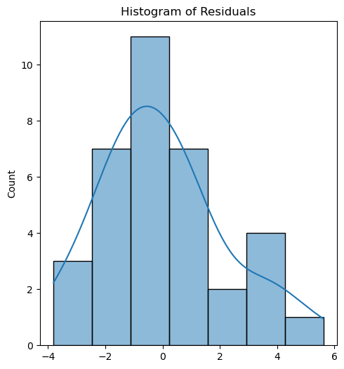

```python
# 1. Visual inspection using histogram and Q-Q plot
plt.figure(figsize=(12, 6))
plt.subplot(1, 2, 1)
sns.histplot(residuals, kde=True)
plt.title("Histogram of Residuals")
```

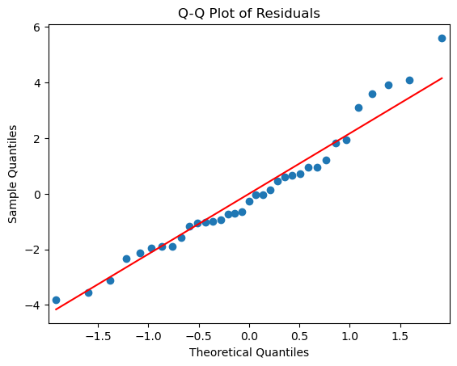

```
Shapiro-Wilk test statistic: 0.9628714919090271, p-value: 0.2783476710319519
Jarque-Bera test statistic: 2.10271117153014, p-value: 0.3494636998596015
```

```python
import statsmodels.api as sm
import matplotlib.pyplot as plt
from scipy.stats import shapiro, jarque_bera

# Fit the model
X = sm.add_constant(df[['Price','Mileage','Top_speed']])
model = sm.OLS(df['Sales'], X).fit()

# Get residuals
residuals = model.resid

# Q-Q plot
sm.qqplot(residuals, line='s')
plt.title('Q-Q Plot of Residuals')
plt.show()

# Shapiro-Wilk Test for normality
shapiro_test = shapiro(residuals)
print(f'Shapiro-Wilk test statistic: {shapiro_test.statistic}, p-value: {shapiro_test.pvalue}')

# Jarque-Bera test
jb_test = jarque_bera(residuals)
print(f'Jarque-Bera test statistic: {jb_test[0]}, p-value: {jb_test[1]}')
```

#### p-value from these tests is > 0.05, the residuals are assumed to be normally distributed.

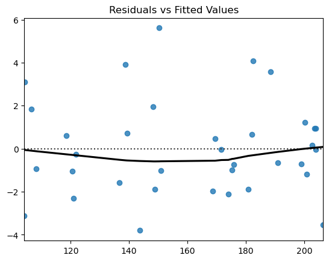

```
Breusch-Pagan test statistic: 1.7884283456540984, p-value: 0.6174562893155353
```

```python
import seaborn as sns
from statsmodels.stats.diagnostic import het_breuschpagan

# Residuals vs. fitted values plot
fitted_values = model.fittedvalues
sns.residplot(x=fitted_values, y=residuals, lowess=True, line_kws={'color': 'Black'})
plt.title('Residuals vs Fitted Values')
plt.show()

# Breusch-Pagan test
bp_test = het_breuschpagan(residuals, model.model.exog)
print(f'Breusch-Pagan test statistic: {bp_test[0]}, p-value: {bp_test[1]}')
```

#### p-value from these tests is > 0.05, the varince at all level of independent variables is constant

### b) Input Variables are Independent of Each Other (No Multicollinearity)

```python
from statsmodels.stats.outliers_influence import variance_inflation_factor

# Calculate VIF for each independent variable
vif_data = pd.DataFrame()
vif_data['feature'] = X.columns
vif_data['VIF'] = [variance_inflation_factor(X.values, i) for i in range(X.shape[1])]

print(vif_data)
```

```
     feature         VIF
0      const  184.048148
1      Price    1.042167
2    Mileage    1.076662
3  Top_speed    1.041262
```

#### VIF value of all the variables are < 5, there is no exist of multicolinearity.

### c) Successive Error Terms are Independent (No Autocorrelation)

```python
from statsmodels.stats.stattools import durbin_watson

# Durbin-Watson test for autocorrelation
dw_stat = durbin_watson(residuals)
print(f'Durbin-Watson statistic: {dw_stat}')
```

```
Durbin-Watson statistic: 1.6547723984064426
```

#### Durbin-Watson statistic value is between 1.5 and 2.5 suggests no significant autocorrelation in the residuals.

### d) Specification Bias (Correct Model Specification)

```python
from statsmodels.stats.outliers_influence import reset_ramsey

# Ramsey RESET test
reset_test = reset_ramsey(model, degree=3)
print(f'Ramsey RESET test statistic: {reset_test.fvalue}, p-value: {reset_test.pvalue}')
```

```
Ramsey RESET test statistic: 0.18007970511136429, p-value: 0.8361304418861545
```

#### p-value is > 0.05, the model is correctly specified

### e) Identify Outliers in Independent Variables (Leverage or Hat Diagonal)

```python
# Get the influence measures (hat diagonal)
influence = model.get_influence()
hat_values = influence.hat_matrix_diag

# Set a threshold for identifying high-leverage points (rule of thumb: 2*(k+1)/n, where k = number of predictors)
n = len(df)
k = X.shape[1] - 1  # number of predictors excluding the intercept
leverage_threshold = 2 * (k + 1) / n

# Identify high-leverage points
high_leverage_points = np.where(hat_values > leverage_threshold)[0]

print(f"High leverage points (outliers in X): {high_leverage_points}")
```

```
High leverage points (outliers in X): []
```

```python
# Get the influence measures (hat diagonal)
influence = model.get_influence()
hat_values = influence.hat_matrix_diag

# Set a threshold for identifying high-leverage points (rule of thumb: 2*(k+1)/n, where k = number of predictors)
n = len(df)
k = X.shape[1] - 1  # number of predictors excluding the intercept
leverage_threshold = 2 * (k + 1) / n

# Identify high-leverage points
high_leverage_points = np.where(hat_values > leverage_threshold)[0]

print(f"High leverage points (outliers in X): {high_leverage_points}")
```

```
High leverage points (outliers in X): []
```

## For Marengo mode

```python
Marengo_data = {
    'Sales': [20.896, 31.048, 29.904, 28.792, 16.776, 18.928, 22.776,36.824, 22.216, 35.456, 28.576, 33.648, 33.44, 34.912, 24.016, 20.992, 21.696, 17.832, 25.624, 21.92, 24.792,22.256, 15.488, 21.64, 23.264, 19.328, 27.216, 23.096, 17.824, 19.144, 21.6],
    'Price': [42.5, 36, 54.7, 42.7, 44.9, 35.5, 51.3, 30.4, 38.4, 32.2, 59.4, 50.8, 57.5, 44.6, 34.6, 56.4, 41.4, 53.7, 44.8, 32.4, 40.9, 44.1, 46.6, 31.4, 54.7, 37.9, 52.9, 42.7, 54.9, 44, 42.2 ],
    'Mileage': [9.3, 9.7, 16.6, 11.7, 13.7, 9.6, 13.7, 12.6, 16.2, 9.6, 11.3, 13.6, 13.5, 11.1, 14.1, 13.4, 12.8, 16, 12.7, 13.6, 11.6, 11.4, 16.3, 14.5, 14.3,  9.4, 15.3, 15, 13.5, 11.8, 9.3],
    'Top_speed': [199.4, 235.2, 240.8, 232.5, 188.8, 184.2, 207.7, 249.5, 175.8, 245.6, 223.3, 240, 250, 247.4, 192, 201.2, 193.3, 202, 208.9, 176.9, 218.2, 190, 176.8, 178.9, 192.3, 184.1, 240.3, 192.1, 199, 181.1, 181.2]
}
```

```python
# Create DataFrame
df1 = pd.DataFrame(Marengo_data)
```

```python
df1
```

|  | Sales | Price | Mileage | Top_speed |
| --- | --- | --- | --- | --- |
| 0 | 20.896 | 42.5 | 9.3 | 199.4 |
| 1 | 31.048 | 36.0 | 9.7 | 235.2 |
| 2 | 29.904 | 54.7 | 16.6 | 240.8 |
| 3 | 28.792 | 42.7 | 11.7 | 232.5 |
| 4 | 16.776 | 44.9 | 13.7 | 188.8 |
| 5 | 18.928 | 35.5 | 9.6 | 184.2 |
| 6 | 22.776 | 51.3 | 13.7 | 207.7 |
| 7 | 36.824 | 30.4 | 12.6 | 249.5 |
| 8 | 22.216 | 38.4 | 16.2 | 175.8 |
| 9 | 35.456 | 32.2 | 9.6 | 245.6 |
| 10 | 28.576 | 59.4 | 11.3 | 223.3 |
| 11 | 33.648 | 50.8 | 13.6 | 240.0 |
| 12 | 33.440 | 57.5 | 13.5 | 250.0 |
| 13 | 34.912 | 44.6 | 11.1 | 247.4 |
| 14 | 24.016 | 34.6 | 14.1 | 192.0 |
| 15 | 20.992 | 56.4 | 13.4 | 201.2 |
| 16 | 21.696 | 41.4 | 12.8 | 193.3 |
| 17 | 17.832 | 53.7 | 16.0 | 202.0 |
| 18 | 25.624 | 44.8 | 12.7 | 208.9 |
| 19 | 21.920 | 32.4 | 13.6 | 176.9 |
| 20 | 24.792 | 40.9 | 11.6 | 218.2 |
| 21 | 22.256 | 44.1 | 11.4 | 190.0 |
| 22 | 15.488 | 46.6 | 16.3 | 176.8 |
| 23 | 21.640 | 31.4 | 14.5 | 178.9 |
| 24 | 23.264 | 54.7 | 14.3 | 192.3 |
| 25 | 19.328 | 37.9 | 9.4 | 184.1 |
| 26 | 27.216 | 52.9 | 15.3 | 240.3 |
| 27 | 23.096 | 42.7 | 15.0 | 192.1 |
| 28 | 17.824 | 54.9 | 13.5 | 199.0 |
| 29 | 19.144 | 44.0 | 11.8 | 181.1 |
| 30 | 21.600 | 42.2 | 9.3 | 181.2 |

```python
# Define independent variables (Price, Mileage, Top Speed)
X = df1[['Price', 'Mileage', 'Top_speed']]
X = sm.add_constant(X)  # Add constant term for intercept
```

```python
# Define dependent variable (Sales)
y = df1['Sales']
```

```python
# Fit the regression model
model1 = sm.OLS(y, X).fit()
```

```python
# isplay the regression results
print(model1.summary())
```

```
                            OLS Regression Results
==============================================================================
Dep. Variable:                  Sales   R-squared:                       0.863
Model:                            OLS   Adj. R-squared:                  0.848
Method:                 Least Squares   F-statistic:                     56.74
Date:                Fri, 25 Oct 2024   Prob (F-statistic):           8.74e-12
Time:                        23:57:11   Log-Likelihood:                -67.757
No. Observations:                  31   AIC:                             143.5
Df Residuals:                      27   BIC:                             149.2
Df Model:                           3
Covariance Type:            nonrobust
==============================================================================
                 coef    std err          t      P>|t|      [0.025      0.975]
------------------------------------------------------------------------------
const        -13.4476      4.454     -3.019      0.005     -22.586      -4.309
Price         -0.1867      0.055     -3.368      0.002      -0.300      -0.073
Mileage        0.0413      0.207      0.200      0.843      -0.383       0.465
Top_speed      0.2208      0.017     12.820      0.000       0.185       0.256
==============================================================================
Omnibus:                        2.082   Durbin-Watson:                   1.649
Prob(Omnibus):                  0.353   Jarque-Bera (JB):                1.181
Skew:                          -0.071   Prob(JB):                        0.554
Kurtosis:                       2.054   Cond. No.                     2.30e+03
==============================================================================

Notes:
[1] Standard Errors assume that the covariance matrix of the errors is correctly specified.
[2] The condition number is large, 2.3e+03. This might indicate that there are
strong multicollinearity or other numerical problems.
```

##### Top speed = 210

```python
Predicted_Sales_of_Marengo= -13.4476 - 0.1867 * 41 + 0.0413 * 15 + 0.2208 * 210
```

```python
Predicted_Sales_of_Marengo
```

```
25.8852
```

```python
# Extracting F-statistic and p-value for overall significance
f_statistic = model1.fvalue
f_p_value = model1.f_pvalue
```

```python
# Display overall significance
print(f"\nF-statistic: {f_statistic:.4f}")
print(f"p-value for overall model: {f_p_value:.4f}")
```

```
F-statistic: 56.7355
p-value for overall model: 0.0000
```

#### F-statistic, 56.7355: The overall model is statistically significant

```python
# Check significance of individual variables
p_values = model1.pvalues
print("\nP-values for individual variables:")
for variable, p_value in p_values.items():
    print(f"{variable}: {p_value:.4f}")
```

```
P-values for individual variables:
const: 0.0055
Price: 0.0023
Mileage: 0.8431
Top_speed: 0.0000
```

```python
# Checking significance of individual variables
significant_variables = p_values[p_values < 0.05]
print("\nSignificant variables (p < 0.05):")
print(significant_variables)
```

```
Significant variables (p < 0.05):
const        5.478963e-03
Price        2.288377e-03
Top_speed    5.388275e-13
dtype: float64
```

#### Price and Top speed have a significant impact on sales.

#### Mileage does not have a statistically significant effect

```python
# Increase by 5%
new_price2 = 41 * 1.05
new_mileage2 = 33 * 1.05
new_top_speed2 = 210 * 1.05
```

```python
predicted_sales_increased = -13.4476 - 0.7950 * new_price2 + 0.0413 * new_mileage2 + 0.2208 * new_top_speed2
print(f"Predicted Sales (in units) after 5% increase: {predicted_sales_increased:.2f}")
```

```
Predicted Sales (in units) after 5% increase: 2.45
```

```python
# Decrease by 5%
new_price3 = 41 * 0.95
new_mileage3 = 33 * 0.95
new_top_speed3 = 210 * 0.95
```

```python
predicted_sales_decreased = -13.4476 - 0.7950 * new_price3 + 0.0413 * new_mileage3 + 0.2208 * new_top_speed3
print(f"Predicted Sales (in units) after 5% decrease: {predicted_sales_decreased:.2f}")
```

```
Predicted Sales (in units) after 5% decrease: 0.93
```

## Testing assumption:

### a) Check if error terms are normally distributed

```python
residuals = model1.resid  # Residuals (errors)
```

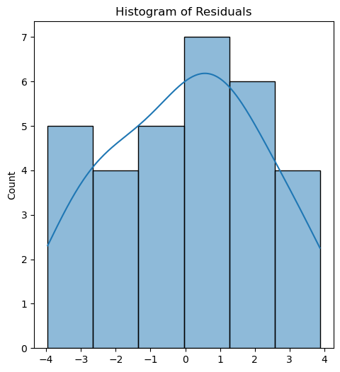

```python
# 1. Visual inspection using histogram and Q-Q plot
plt.figure(figsize=(12, 6))
plt.subplot(1, 2, 1)
sns.histplot(residuals, kde=True)
plt.title("Histogram of Residuals")
```

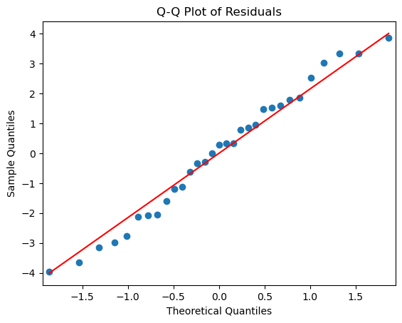

```python
import statsmodels.api as sm
import matplotlib.pyplot as plt
from scipy.stats import shapiro, jarque_bera

# Fit the model
X = sm.add_constant(df1[['Price','Mileage','Top_speed']])
model1 = sm.OLS(df1['Sales'], X).fit()

# Get residuals
residuals1 = model1.resid

# Q-Q plot
sm.qqplot(residuals1, line='s')
plt.title('Q-Q Plot of Residuals')
plt.show()
```

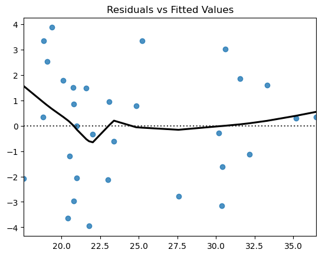

```
Breusch-Pagan test statistic: 7.394947338592958, p-value: 0.060320039874715875
```

```python
# Residuals vs. fitted values plot
fitted_values = model1.fittedvalues
sns.residplot(x=fitted_values, y=residuals1, lowess=True, line_kws={'color': 'black'})
plt.title('Residuals vs Fitted Values')
plt.show()

# Breusch-Pagan test
bp_test = het_breuschpagan(residuals1, model1.model.exog)
print(f'Breusch-Pagan test statistic: {bp_test[0]}, p-value: {bp_test[1]}')
```

#### p-value from these tests is > 0.05, the varince at all level of independent variables is constant

### b) Input Variables are Independent of Each Other (No Multicollinearity)

```python
# Calculate VIF for each independent variable
vif_data = pd.DataFrame()
vif_data['feature'] = X.columns
vif_data['VIF'] = [variance_inflation_factor(X.values, i) for i in range(X.shape[1])]

print(vif_data)
```

```
     feature         VIF
0      const  115.565519
1      Price    1.232176
2    Mileage    1.184425
3  Top_speed    1.090848
```

#### VIF value of all the variables are < 5, there is no exist of multicolinearity.

### c) Successive Error Terms are Independent (No Autocorrelation)

```python
# Durbin-Watson test for autocorrelation
dw_stat = durbin_watson(residuals)
print(f'Durbin-Watson statistic: {dw_stat}')
```

```
Durbin-Watson statistic: 1.649289430373179
```

#### Durbin-Watson statistic value is between 1.5 and 2.5 suggests no significant autocorrelation in the residuals.

### d) Specification Bias (Correct Model Specification)

```python
# Ramsey RESET test
reset_test = reset_ramsey(model1, degree=3)
print(f'Ramsey RESET test statistic: {reset_test.fvalue}, p-value: {reset_test.pvalue}')
```

```
Ramsey RESET test statistic: 0.39196911930681577, p-value: 0.6798051582842561
```

#### p-value is > 0.05, the model is correctly specified

### Q-5) Based on the sales prediction, calculate the overall projected profit for the Rocinante36 and Marengo32 models, respectively?

```python
Predicted_sales_Rocinante = 225.29 # in units
Price_per_unit_Rocinante = 7  # in lakh rupees
Cost_per_unit_Rocinante = 6 # in lakh rupees
```

```python
# Calculate revenue and profit for Rocinante36
Revenue_Rocinante = Predicted_sales_Rocinante * Price_per_unit_Rocinante
Total_costs_Rocinante = Predicted_sales_Rocinante * Cost_per_unit_Rocinante
Profit_Rocinante = Revenue_Rocinante - Total_costs_Rocinante
```

```python
Predicted_sales_Marengo = 25.88 # in units
Price_per_unit_Marengo = 41  # in lakh rupees
Cost_per_unit_Marengo = 33 # in lakh rupees
```

```python
# Calculate revenue and profit for Marengo
Revenue_Marengo = Predicted_sales_Marengo * Price_per_unit_Marengo
Total_costs_Marengo = Predicted_sales_Marengo * Cost_per_unit_Marengo
Profit_Marengo = Revenue_Marengo - Total_costs_Marengo
```

```python
# Display the results
print(f"Overall Predicted Profit for Rocinante36 Model: {Profit_Rocinante:.2f} lakh rupees")
print(f"Overall Predicted Profit for Marengo32 Model: {Profit_Marengo:.2f} lakh rupees")
```

```
Overall Predicted Profit for Rocinante36 Model: 225.29 lakh rupees
Overall Predicted Profit for Marengo32 Model: 207.04 lakh rupees
```

### Q-7) You must have developed the regression equation for both the models, Rocinante36 and Marengo32. Suppose you increase the price of Rocinante36 and Marengo32 by ₹1 lakh each. Which of the two models will have to see a higher impact on sales numbers? Provide proper logic for your answer. (Note: You can assume that all the other specifications, such as mileage and top speed, are the same for both models.)

```python
# Coefficients for Rocinante36
Price_Rocinante = -0.7950
# Coefficients for Marengo32
Price_Marengo = -0.1867
```

```python
# Price increase
price_increase = 1  # 1 lakh rupees
```

```python
# Calculate expected change in sales
Change_in_sales_Rocinante = Price_Rocinante * price_increase
Change_in_sales_Marengo = Price_Marengo * price_increase
```

```python
# Display the results
print(f"Expected Change in Sales for Rocinante36 due to price increase: {Change_in_sales_Rocinante:.2f} units")
print(f"Expected Change in Sales for Marengo32 due to price increase: {Change_in_sales_Marengo:.2f} units")
```

```
Expected Change in Sales for Rocinante36 due to price increase: -0.80 units
Expected Change in Sales for Marengo32 due to price increase: -0.19 units
```

```python
# Determine which model is more affected
if abs(Change_in_sales_Rocinante ) > abs(Change_in_sales_Marengo):
    print("Rocinante36 is more affected by the price increase.")
else:
    print("Marengo32 is more affected by the price increase.")
```

```
Rocinante36 is more affected by the price increase.
```

### Q-8) After developing the regression equation for both the models (Rocinante36 and Marengo32), if you analyse the p-values for the coefficients in the regression results, you will notice that some of the regression variables (top speed, mileage and price) are insignificant. Drop the insignificant regression variables and rebuild the regression model using only significant variables. Compare the adjusted R-squared value for both the new and the old regression models. Do you notice any change in the adjusted R-squared value? If yes, explain the reason for the change

#### For Rocinante model

```python
# Define independent variables (Price, Mileage)
X = df[["Price", "Mileage"]]
X = sm.add_constant(X)  # Add a constant (intercept term)
```

```python
# Define the dependent variable (Sales)
y = df["Sales"]
```

```python
# Fit the regression model
model = sm.OLS(y, X).fit()
```

```python
# Display the regression results
print(model.summary())
```

```
                            OLS Regression Results
==============================================================================
Dep. Variable:                  Sales   R-squared:                       0.996
Model:                            OLS   Adj. R-squared:                  0.995
Method:                 Least Squares   F-statistic:                     3718.
Date:                Fri, 25 Oct 2024   Prob (F-statistic):           1.29e-38
Time:                        23:57:12   Log-Likelihood:                -77.017
No. Observations:                  35   AIC:                             160.0
Df Residuals:                      32   BIC:                             164.7
Df Model:                           2
Covariance Type:            nonrobust
==============================================================================
                 coef    std err          t      P>|t|      [0.025      0.975]
------------------------------------------------------------------------------
const         47.7800      2.113     22.608      0.000      43.475      52.085
Price         -0.7829      0.251     -3.119      0.004      -1.294      -0.272
Mileage        8.2945      0.097     85.257      0.000       8.096       8.493
==============================================================================
Omnibus:                        1.906   Durbin-Watson:                   1.656
Prob(Omnibus):                  0.386   Jarque-Bera (JB):                1.567
Skew:                           0.509   Prob(JB):                        0.457
Kurtosis:                       2.805   Cond. No.                         91.0
==============================================================================

Notes:
[1] Standard Errors assume that the covariance matrix of the errors is correctly specified.
```

#### For Marengo model

```python
# Define independent variables (Price,Top speed)
X = df1[["Price", "Top_speed"]]
X = sm.add_constant(X)  # Add a constant (intercept term)
```

```python
# Define the dependent variable (Sales)
y = df1["Sales"]
```

```python
# Fit the regression model
model = sm.OLS(y, X).fit()
```

```python
# Display the regression results
print(model.summary())
```

```
                            OLS Regression Results
==============================================================================
Dep. Variable:                  Sales   R-squared:                       0.863
Model:                            OLS   Adj. R-squared:                  0.853
Method:                 Least Squares   F-statistic:                     88.10
Date:                Fri, 25 Oct 2024   Prob (F-statistic):           8.30e-13
Time:                        23:57:12   Log-Likelihood:                -67.779
No. Observations:                  31   AIC:                             141.6
Df Residuals:                      28   BIC:                             145.9
Df Model:                           2
Covariance Type:            nonrobust
==============================================================================
                 coef    std err          t      P>|t|      [0.025      0.975]
------------------------------------------------------------------------------
const        -12.9701      3.694     -3.511      0.002     -20.536      -5.404
Price         -0.1825      0.050     -3.627      0.001      -0.286      -0.079
Top_speed      0.2201      0.017     13.254      0.000       0.186       0.254
==============================================================================
Omnibus:                        2.394   Durbin-Watson:                   1.650
Prob(Omnibus):                  0.302   Jarque-Bera (JB):                1.258
Skew:                          -0.059   Prob(JB):                        0.533
Kurtosis:                       2.020   Cond. No.                     1.94e+03
==============================================================================

Notes:
[1] Standard Errors assume that the covariance matrix of the errors is correctly specified.
[2] The condition number is large, 1.94e+03. This might indicate that there are
strong multicollinearity or other numerical problems.
```

#### adjusted R Sqaure value of Marengo32 model before and removing insignificant variables: 0.848 and 0.853 respectively

#### In the Marengo32 model, the adjusted R-squared value increased, indicating that the significant variables were more effective at explaining the variation in the dependent variable without the presence of insignificant variables.